# **TAREA 1**

Andrea Santoyo Vega

```python
import yfinance as yf
import pandas as pd
import matplotlib.pyplot as plt
import numpy as np
```

| Ticker | Empresa | Actividad principal | Sector / Industria |
| --- | --- | --- | --- |
| PRGO | Perrigo Company plc | Productos de autocuidado (OTC), genéricos y salud accesible | Salud / Farmacéutico |
| ORCL | Oracle Corporation | Bases de datos, software empresarial, y servicios en la nube | Tecnología – Software / Infraestructura |
| GOOG | Alphabet Inc. (Clase C) | Servicios de internet, publicidad digital, cloud, IA, proyectos tech | Tecnología / Servicios de Comunicación |

- PRGO: Perrigo Company plc

Perrigo es una compañía farmacéutica centrada en el desarrollo, la manufactura y comercialización de productos de autocuidado, medicamentos genéricos, además de ingredientes farmacéuticos activos (API). Se especializa en ofrecer soluciones de salud de alta calidad a precios accesibles para consumidores

Sector económico: Sector Salud/Farmacéutico (Healthcare), con énfasis en productos de autocuidado y farmacéuticos de venta libre.

- ORCL: Oracle Corporation

Oracle es una empresa tecnológica estadounidense especializada en soluciones empresariales de software y hardware. Es ampliamente reconocida por su sistema de gestión de bases de datos relacionales (Oracle Database), servicios en la nube (IaaS, PaaS, SaaS) y herramientas para soluciones empresariales como ERP, middleware y sistemas operativos.

Sector económico: Sector Tecnología, industria de Software, Infraestructura y servicios en la nube

- GOOG: Alphabet Inc.

Alphabet Inc. es una empresa holding multinacional de tecnología, matriz de Google. Opera en diversos sectores: servicios de internet (como búsquedas, publicidad digital, YouTube, Android), computación en la nube, inteligencia artificial y otros proyectos tecnológicos (como Waymo, Verily, Calico).

Sector económico: Sector Tecnología o Servicios de Comunicación, en la industria de Internet / Software & IT Services

```python
tickers = ['PRGO', 'ORCL', 'GOOG']
```

```python
prices =yf.download(tickers, start='2018-01-01', end='2025-05-27')['Close']
prices
```

| Ticker Date | GOOG | ORCL | PRGO |
| --- | --- | --- | --- |
| 2018-01-02 | 52.935345 | 41.432018 | 73.287331 |
| 2018-01-03 | 53.804184 | 42.391621 | 73.083038 |
| 2018-01-04 | 53.999023 | 42.809235 | 74.423126 |
| 2018-01-05 | 54.785843 | 43.066914 | 74.504845 |
| 2018-01-08 | 55.019951 | 43.520050 | 73.646820 |
| ... | ... | ... | ... |
| 2025-05-19 | 167.668457 | 159.301498 | 26.580814 |
| 2025-05-20 | 165.121536 | 159.970078 | 26.795807 |
| 2025-05-21 | 169.855835 | 156.846710 | 26.297417 |
| 2025-05-22 | 171.773529 | 156.976440 | 25.799026 |
| 2025-05-23 | 169.386398 | 155.639282 | 25.955383 |

1859 rows × 3 columns

## Rendimiento diario

```python
dailyreturns_GOOG=prices['GOOG'].pct_change()
dailyreturns_GOOG
```

| Date | GOOG |
| --- | --- |
| 2018-01-02 | NaN |
| 2018-01-03 | 0.016413 |
| 2018-01-04 | 0.003621 |
| 2018-01-05 | 0.014571 |
| 2018-01-08 | 0.004273 |
| ... | ... |
| 2025-05-19 | 0.002628 |
| 2025-05-20 | -0.015190 |
| 2025-05-21 | 0.028672 |
| 2025-05-22 | 0.011290 |
| 2025-05-23 | -0.013897 |

1859 rows × 1 columns

**dtype:** float64

```python
dailyreturns_ORCL=prices['ORCL'].pct_change()
dailyreturns_ORCL
```

| Date | ORCL |
| --- | --- |
| 2018-01-02 | NaN |
| 2018-01-03 | 0.023161 |
| 2018-01-04 | 0.009851 |
| 2018-01-05 | 0.006019 |
| 2018-01-08 | 0.010522 |
| ... | ... |
| 2025-05-19 | -0.005296 |
| 2025-05-20 | 0.004197 |
| 2025-05-21 | -0.019525 |
| 2025-05-22 | 0.000827 |
| 2025-05-23 | -0.008518 |

1859 rows × 1 columns

**dtype:** float64

```python
dailyreturns_PRGO=prices['PRGO'].pct_change()
dailyreturns_PRGO
```

| Date | PRGO |
| --- | --- |
| 2018-01-02 | NaN |
| 2018-01-03 | -0.002788 |
| 2018-01-04 | 0.018337 |
| 2018-01-05 | 0.001098 |
| 2018-01-08 | -0.011516 |
| ... | ... |
| 2025-05-19 | 0.005545 |
| 2025-05-20 | 0.008088 |
| 2025-05-21 | -0.018600 |
| 2025-05-22 | -0.018952 |
| 2025-05-23 | 0.006061 |

1859 rows × 1 columns

**dtype:** float64

## Distribuciones

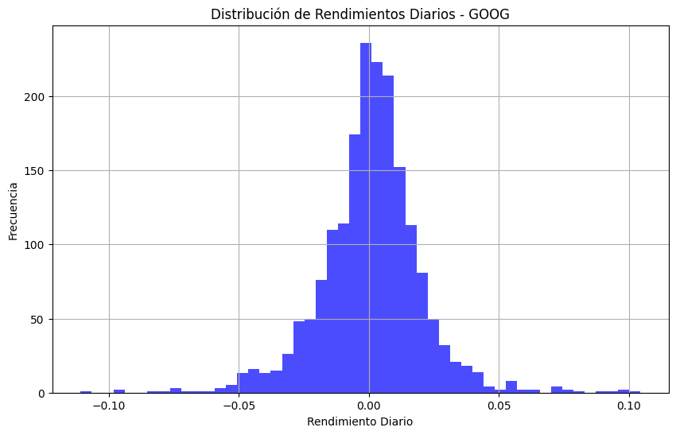

```python
plt.figure(figsize=(10, 6))
plt.hist(dailyreturns_GOOG.dropna(), bins=50, alpha=0.7, color='blue')
plt.title('Distribución de Rendimientos Diarios - GOOG')
plt.xlabel('Rendimiento Diario')
plt.ylabel('Frecuencia')
plt.grid(True)
plt.show()
```

Con esta gráfica podemos ver que tiene una distribución "normal" es decir que las probabilidades de ganacia y perdida son apoximadamente 50/50.

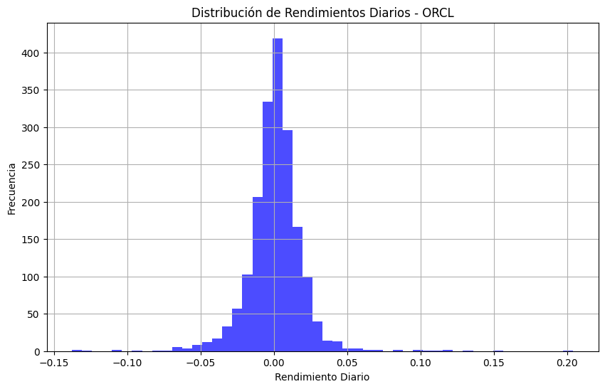

```python
plt.figure(figsize=(10, 6))
plt.hist(dailyreturns_ORCL.dropna(), bins=50, alpha=0.7, color='blue')
plt.title('Distribución de Rendimientos Diarios - ORCL')
plt.xlabel('Rendimiento Diario')
plt.ylabel('Frecuencia')
plt.grid(True)
plt.show()
```

En cambio, en esta gráfica podemos ver como la cola está más alargada hacia el lado derecho (distribución simétrica positiva) dandole más peso y probabilidad a rendimientos positivos que negativos.

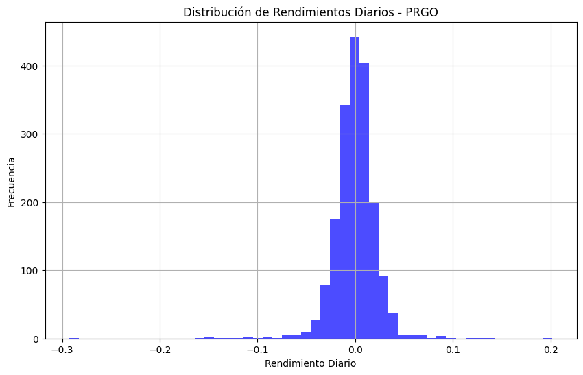

```python
plt.figure(figsize=(10, 6))
plt.hist(dailyreturns_PRGO.dropna(), bins=50, alpha=0.7, color='blue')
plt.title('Distribución de Rendimientos Diarios - PRGO')
plt.xlabel('Rendimiento Diario')
plt.ylabel('Frecuencia')
plt.grid(True)
plt.show()
```

Aquí la distribución está ligeramente sesgada hacia la izquierda, podemos ver en la gráfica que del lado negativo casi llega al -0.3, por lo que concluimos que hay más probabilidad de que haya rendimientos negativos que positivos.